# Model assumptions

assumptions

Author

Affiliation

Daniela Palleschi

Humboldt-Universität zu Berlin

Published

April 13, 2023

```r
knitr::opts_chunk$set(eval = T, # change this to 'eval = T' to reproduce the analyses; make sure to comment out
                      echo = T, # 'print code chunk?'
                      message = F, # 'print messages (e.g., warnings)?'
                      error = F,
                      warning = F)
```

# Learning objectives

Today we will learn…

- how to check model assumptions
- how to transform our data to meet model assumptions

# Resources

Sections 6.3, 6.4 and 7.9 in Winter (2019)

# Set-up

1. Start with a clean R Environment (Session > Restart R).
2. Suppress scientific notation (make very small numbers easier to read):

```r
# suppress scientific notation
options(scipen=999)
```

## Packages

```r
pacman::p_load(tidyverse,
               broom,
               patchwork,
               sjPlot,
               knitr,
               kableExtra,
               Rmisc)
```

## Data

```r
# load in dataset
df_crit_verb <-
  readr::read_csv(
    here::here("data/tidy_data_lifetime_pilot.csv"),
    # for special characters
    locale = readr::locale(encoding = "latin1")
  ) |>
  mutate_if(is.character, as.factor) |> # all character variables as factor
  mutate(lifetime = fct_relevel(lifetime, "living", "dead"),
         tense = fct_relevel(tense, "PP", "SF")) |>
  filter(type == "critical", # only critical trials
         px != "px3", # px3 had a lot of missing values
         fp > 0, # only values of fp above 0
         region == "verb") %>% # critical region only
  droplevels() # remove any factor levels with no observations
```

# 1 Review: (multiple) linear regression

- when we run a linear model, we are fitting a line (predicted values) to our data (observed values)
  - the *intercept* is the *predicted* value of *y* (our outcome) when *x* (our predictor) is 0
  - the *slope* is the *predicted* change in *y* with an increase of 1-unit of *x*
  - the *residuals* measure the *difference* between our *predicted values* of *y* from the *observed values* of *y*

$$\begin{align}
observed\;values &= fitted\;values + residuals\\
residuals &= observed\;values - fitted\;values
\end{align}$$

## 1.1 Our model

### 1.1.1 Check contrasts

```r
contrasts(df_crit_verb$lifetime)
```

```
       dead
living    0
dead      1
```

```r
contrasts(df_crit_verb$tense)
```

```
   SF
PP  0
SF  1
```

### 1.1.2 Re-order predictor levels

```r
# set contrasts
df_crit_verb <- df_crit_verb %>%
  mutate(lifetime = fct_relevel(lifetime, "living", "dead"),
         tense = fct_relevel(tense, "PP", "SF"))
```

### 1.1.3 Set sum coding

Set contrasts

```r
contrasts(df_crit_verb$lifetime) <- c(-0.5, +0.5)
contrasts(df_crit_verb$tense) <- c(-0.5, +0.5)
```

Check contrasts

```r
contrasts(df_crit_verb$lifetime)
```

```
       [,1]
living -0.5
dead    0.5
```

```r
contrasts(df_crit_verb$tense)
```

```
   [,1]
PP -0.5
SF  0.5
```

### 1.1.4 Run model

```r
# fit linear model
fit_fp <- df_crit_verb %>%
  lm(fp ~ lifetime*tense, data = .)
```

### 1.1.5 Print summary

```r
summary(fit_fp)
```

```
Call:
lm(formula = fp ~ lifetime * tense, data = .)

Residuals:
    Min      1Q  Median      3Q     Max
-240.62 -108.69  -27.62   56.20  778.65

Coefficients:
                 Estimate Std. Error t value            Pr(>|t|)
(Intercept)        309.06       6.26  49.367 <0.0000000000000002 ***
lifetime1           31.52      12.52   2.517              0.0121 *
tense1             -12.75      12.52  -1.018              0.3090
lifetime1:tense1   -21.69      25.04  -0.866              0.3868
---
Signif. codes:  0 '***' 0.001 '**' 0.01 '*' 0.05 '.' 0.1 ' ' 1

Residual standard error: 145.9 on 539 degrees of freedom
Multiple R-squared:  0.01499,   Adjusted R-squared:  0.009506
F-statistic: 2.734 on 3 and 539 DF,  p-value: 0.04306
```

# 2 Assumptions

- refer to *residuals*
  - i.e., the difference between the observed and the fitted (predicted) values
1. *normality assumption*
   - residuals of the model are (approximately) normally distributed
2. *constant variance assumption* (homoscedasticity)
   - spread of residuals should be (approximately) equal along the regression line
3. absence of *collinearity*
   - predictors should not be correlated with each other
4. *independence*
   - data points should be independent from each other

## 2.1 Checking assumptions

- we typically assess **normality** and **homoscedasticity** visually with histograms, Q-Q plots, and residual plots
- we can assess collinearity with VIFs
- the assumption of independence is dealt with conceptually

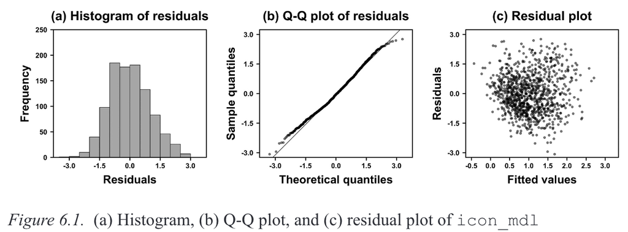

Image source: Winter (2019) (all rights reserved)

# 3 Constant variance: Residual plot

- doesn’t look like a blob with categorical data, but rather stripes
  - what’s important is that the distribution (vertically) is roughly similar across stripes
  - why are predicted values for categorical data stripey?

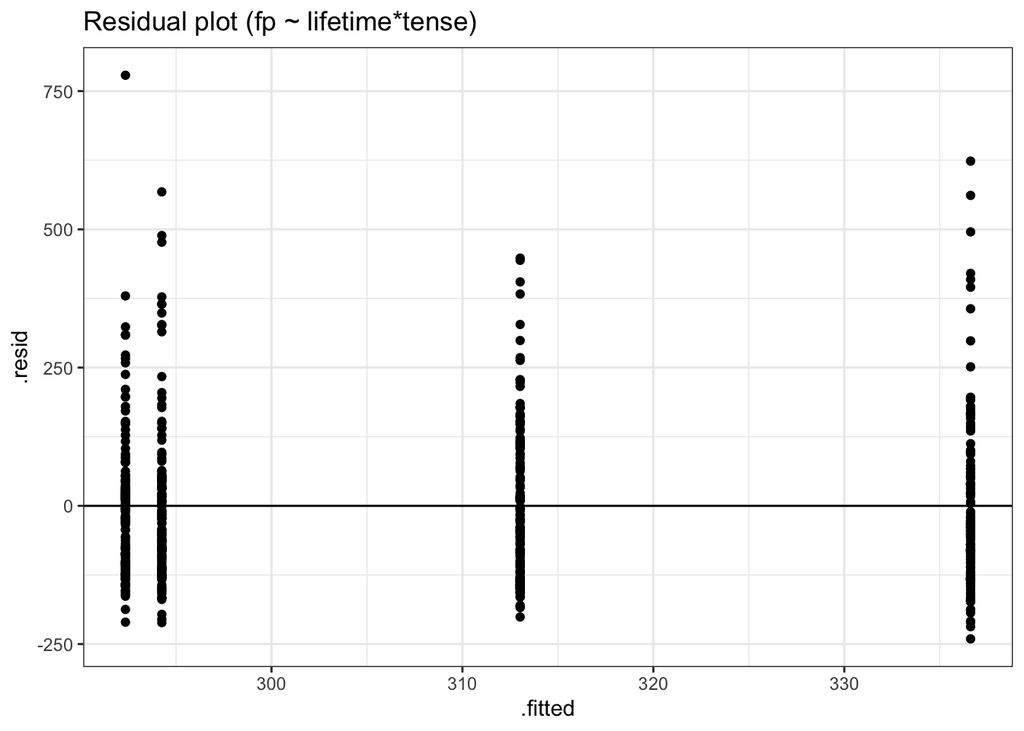

# 4 Normality assumption

- can be inspected e.g., with a histogram or Q-Q plot

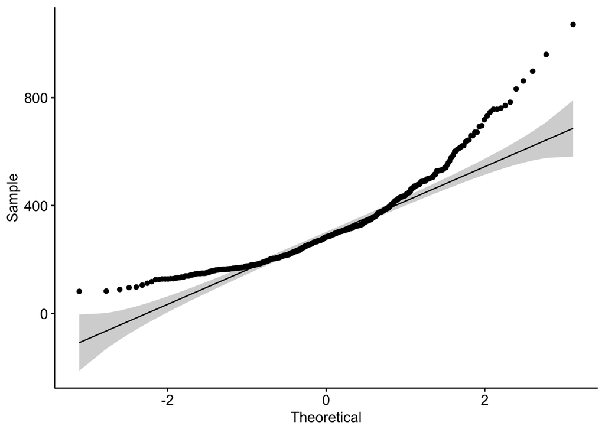

```r
df_crit_verb |>
  filter(fp > 0) |>
  mutate(half = if_else(trial >= 104, "1st","2nd")) |>
  ggpubr::ggqqplot(x = "fp")
```

## Normality assumption

- how about by participant and experimental half?

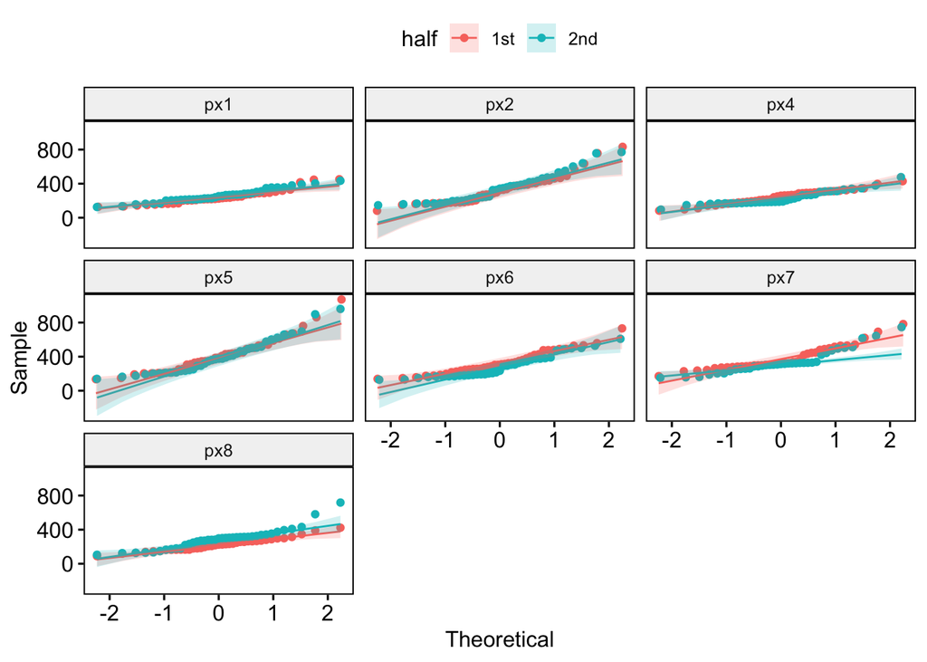

```r
df_crit_verb |>
  filter(fp > 0) |>
  mutate(half = if_else(trial >= 104, "1st","2nd")) |>
  ggpubr::ggqqplot(x = "fp",
                    color = "half",
                    facet.by = "px")
```

## Normality assumption

- normal distribution is symmetrical, are our residuals normally distributed?

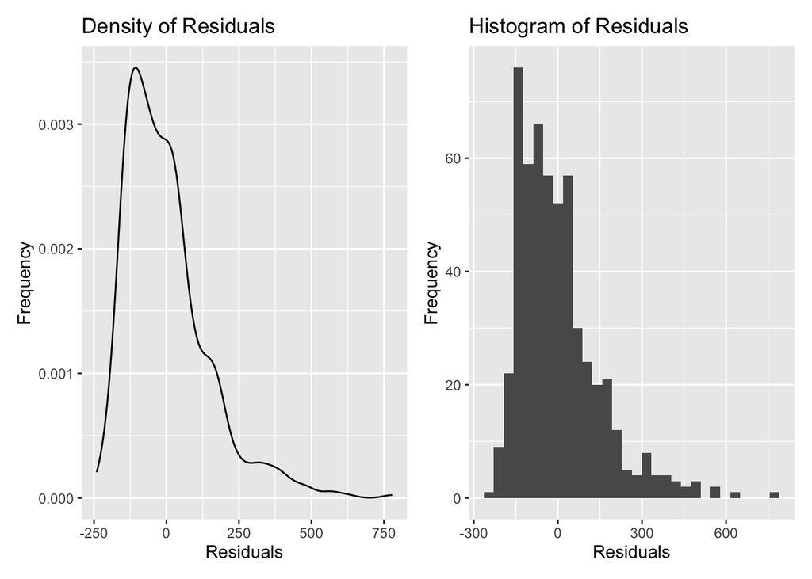

Figure 1: Visualising normality of residuals

## Normality assumption

- reading time data tends to be *positively skewed*
  - so the residuals also tend to be positively skewed
- data with a skewed distribution do not meet the normality assumption
- a fix: nonlinear transformations
  - the most common: the log transformation
- log-transforming your data makes larger numbers smaller (and small numbers smaller too)
  - the difference between smaller numbers and larger numbers shrinks
  - can make skewed data normally distributed

### 4.0.1 Log transformation

- for more see Section 5.4 in Winter (2019)
- the R funtion `log()` computes the ‘natural logarithm’ (and is the inverse of the exponential `exp()`)
- `log()` makes large numbers smaller
- `exp()` makes small numbers larger

```r
log(2)
```

```
[1] 0.6931472
```

```r
log(1:10)
```

```
 [1] 0.0000000 0.6931472 1.0986123 1.3862944 1.6094379 1.7917595 1.9459101
 [8] 2.0794415 2.1972246 2.3025851
```

```r
log(c(10,20,30,40,100))
```

```
[1] 2.302585 2.995732 3.401197 3.688879 4.605170
```

```r
exp(1:10)
```

```
 [1]     2.718282     7.389056    20.085537    54.598150   148.413159
 [6]   403.428793  1096.633158  2980.957987  8103.083928 22026.465795
```

```r
exp(log(1:10))
```

```
 [1]  1  2  3  4  5  6  7  8  9 10
```

## 4.1 Fit model (log-transformed)

- continuous variables truncated at 0 typically have a *positive skew*
  - a lot of small values (e.g., `tt` < 500ms), with some larger values (> `tt` 1000)
  - this usually means our residuals are also positively skewed, i.e., not normally distributed
- so we typically log-transform raw reading/reaction times for our linear models

```r
# fit simple linear model with log
fit_fp_log <- df_crit_verb %>%
  filter(fp > 0) %>% # important! you can't log transform 0
  lm(log(fp) ~ lifetime*tense, data = .)
summary(fit_fp_log)
```

```
Call:
lm(formula = log(fp) ~ lifetime * tense, data = .)

Residuals:
     Min       1Q   Median       3Q      Max
-1.18141 -0.34282  0.00058  0.26923  1.38822

Coefficients:
                 Estimate Std. Error t value             Pr(>|t|)
(Intercept)       5.63477    0.01877 300.193 < 0.0000000000000002 ***
lifetime1         0.10130    0.03754   2.698              0.00718 **
tense1           -0.03357    0.03754  -0.894              0.37158
lifetime1:tense1 -0.08320    0.07508  -1.108              0.26828
---
Signif. codes:  0 '***' 0.001 '**' 0.01 '*' 0.05 '.' 0.1 ' ' 1

Residual standard error: 0.4374 on 539 degrees of freedom
Multiple R-squared:  0.01712,   Adjusted R-squared:  0.01165
F-statistic: 3.129 on 3 and 539 DF,  p-value: 0.02538
```

### 4.1.1 Check assumptions

Raw first-pass reading times

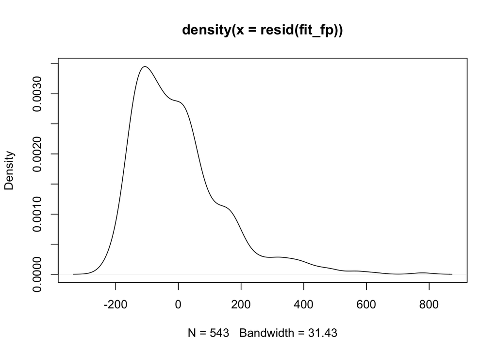

```r
plot(density(resid(fit_fp)))
```

Log first-pass reading times

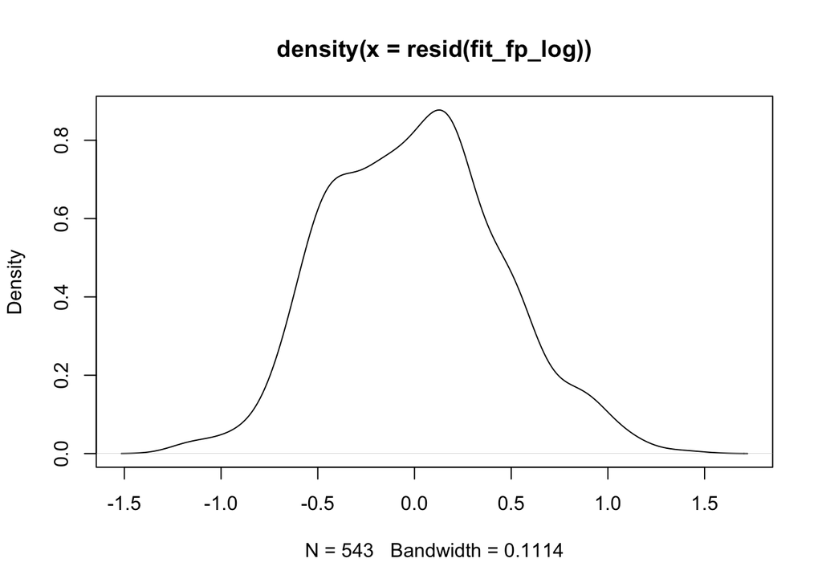

```r
plot(density(resid(fit_fp_log)))
```

### Check assumptions

Raw first-pass reading times

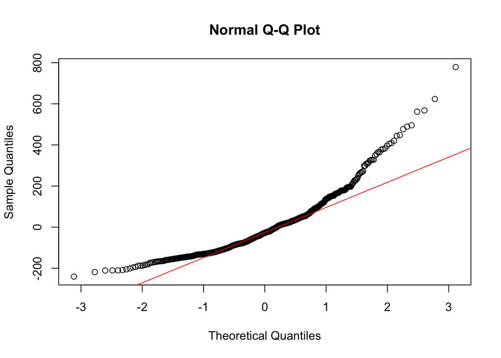

```r
qqnorm(residuals(fit_fp))
qqline(residuals(fit_fp), col="red")
```

Log first-pass reading times

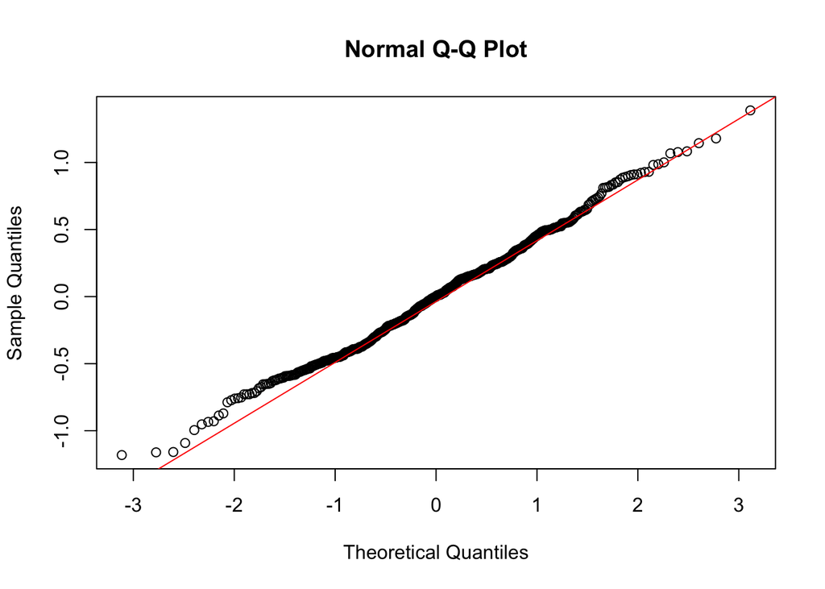

```r
qqnorm(residuals(fit_fp_log))
qqline(residuals(fit_fp_log), col="red")
```

### Check assumptions: constant variance

Raw first-pass reading times

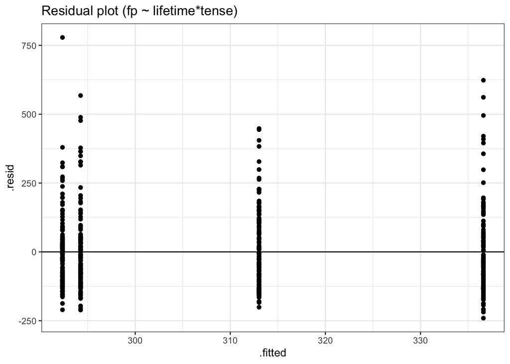

```r
fit_fp %>%
ggplot(aes(x = .fitted, y = .resid)) +
  labs(title = "Residual plot (fp ~ lifetime*tense)") +
  geom_point() +
  geom_hline(yintercept = 0) +
  theme_bw()  # Add theme for cleaner look
```

Log first-pass reading times

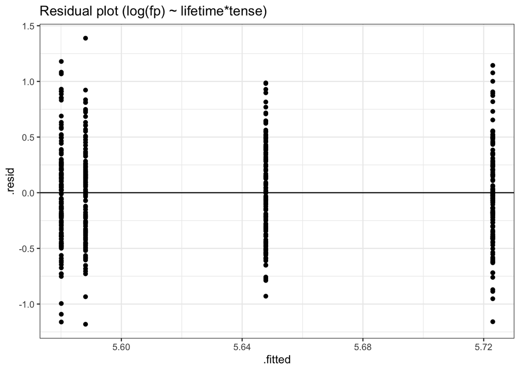

```r
fit_fp_log %>%
ggplot(aes(x = .fitted, y = .resid)) +
  labs(title = "Residual plot (log(fp) ~ lifetime*tense)") +
  geom_point() +
  geom_hline(yintercept = 0) +
  theme_bw()  # Add theme for cleaner look
```

### 4.1.2 Approaching normality: log

- so it seems like the log-transformed values have made the data more normal